# Lab 6: Machine Learning in Hydrology

Using Tidymodels & CAMELS Data

Author

Avery Eastman

## Load necessary libraries

```r
library(tidyverse)
library(tidymodels)
library(powerjoin)
library(glue)
library(vip)
library(baguette)
```

## Download data and documentation PDF

```r
root  <- 'https://gdex.ucar.edu/dataset/camels/file'

download.file('https://gdex.ucar.edu/dataset/camels/file/camels_attributes_v2.0.pdf',
              'data/camels_attributes_v2.0.pdf')
```

## Getting basin characteristics

```r
types <- c("clim", "geol", "soil", "topo", "vege", "hydro")

remote_files  <- glue('{root}/camels_{types}.txt')
local_files   <- glue('data/camels_{types}.txt')

walk2(remote_files, local_files, download.file, quiet = TRUE)

camels <- map(local_files, read_delim, show_col_types = FALSE)

camels <- power_full_join(camels ,by = 'gauge_id')
```

## Question 1

#### Make sure all data and the PDF are downloaded into you data directory

#### From the documentation PDF, report what zero_q_freq represents

Based on the PDF, zero_q_freq represents the frequency of days with zero streamflow, which is recorded as a percentage.

## Question 2

#### Make 2 maps of the sites, coloring the points by the aridty and p_mean column. Add clear labels, titles, and a color scale that makes sense for each parameter. Ensure these render as a single image with your choice of facet_*, patchwork, or ggpubr.

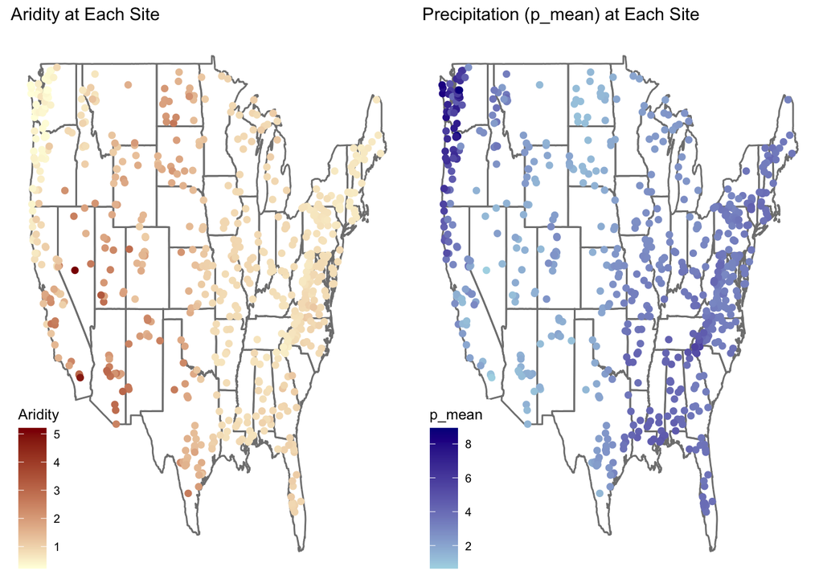

```r
library(ggplot2)
library(ggthemes)
library(ggpubr)

map_aridity <- ggplot(data = camels, aes(x = gauge_lon, y = gauge_lat)) +
  borders("state", colour = "gray50") +
  geom_point(aes(color = aridity)) +
  scale_color_gradient(low = "lightyellow", high = "darkred") +
  ggtitle("Aridity at Each Site") +
  theme_map() +
  labs(color = "Aridity")

map_p_mean <- ggplot(data = camels, aes(x = gauge_lon, y = gauge_lat)) +
  borders("state", colour = "gray50") +
  geom_point(aes(color = p_mean)) +
  scale_color_gradient(low = "lightblue", high = "darkblue") +
  ggtitle("Precipitation (p_mean) at Each Site") +
  theme_map() +
  labs(color = "p_mean")

aridity_and_percipitation <- ggarrange(map_aridity, map_p_mean, ncol = 2, nrow = 1)

aridity_and_percipitation
```

```r
ggsave("images/aridity_and_percipitation.png", width = 10, height = 5, dpi = 300)
```

## Model Building

#### Splitting the data

```r
set.seed(123)
# Bad form to perform simple transformations on the outcome variable within a recipe. So, we'll do it here.
camels <- camels |>
  mutate(logQmean = log(q_mean))

# Generate the split
camels_split <- initial_split(camels, prop = 0.8)
camels_train <- training(camels_split)
camels_test  <- testing(camels_split)

camels_cv <- vfold_cv(camels_train, v = 10)
```

#### Preprocessor: recipe

```r
# Create a recipe to preprocess the data
rec <-  recipe(logQmean ~ aridity + p_mean, data = camels_train) |>
  # Log transform the predictor variables (aridity and p_mean)
  step_log(all_predictors()) |>
  # Add an interaction term between aridity and p_mean
  step_interact(terms = ~ aridity:p_mean) |>
  # Drop any rows with missing values in the pred
  step_naomit(all_predictors(), all_outcomes())
```

## Linear regression and random forest models

```r
lm_model <- linear_reg() |>
  # define the engine
  set_engine("lm") |>
  # define the mode
  set_mode("regression")

rf_model <- rand_forest() |>
  set_engine("ranger", importance = "impurity") |>
  set_mode("regression")
```

## Workflow_set approach

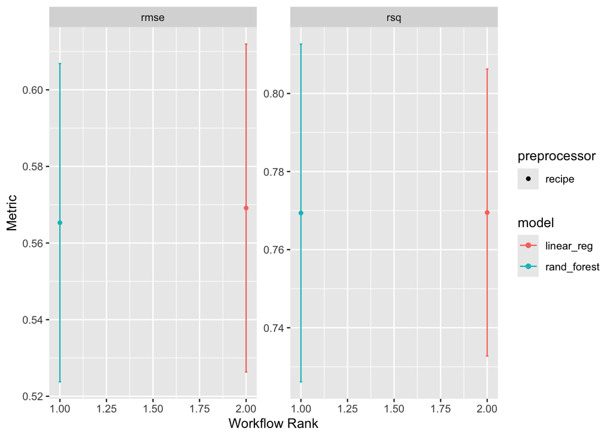

```r
wf <- workflow_set(list(rec), list(lm_model, rf_model)) %>%
  workflow_map('fit_resamples', resamples = camels_cv)

autoplot(wf)
```

```r
rank_results(wf, rank_metric = "rsq", select_best = TRUE)
```

```
# A tibble: 4 × 9
  wflow_id          .config .metric  mean std_err     n preprocessor model  rank
  <chr>             <chr>   <chr>   <dbl>   <dbl> <int> <chr>        <chr> <int>
1 recipe_linear_reg Prepro… rmse    0.569  0.0260    10 recipe       line…     1
2 recipe_linear_reg Prepro… rsq     0.770  0.0223    10 recipe       line…     1
3 recipe_rand_fore… Prepro… rmse    0.565  0.0253    10 recipe       rand…     2
4 recipe_rand_fore… Prepro… rsq     0.769  0.0263    10 recipe       rand…     2
```

## Question 3

#### Build a xgboost (engine) regression (mode) model using boost_tree

```r
bt_model <- boost_tree() |>
  set_engine("xgboost") |>
  set_mode("regression")
```

#### Build a neural network model using the nnet engine from the baguette package using the bag_mlp function

```r
bag_model <- bag_mlp() |>
  set_engine("nnet") |>
  set_mode("regression")
```

#### Add this to the above workflow

```r
wf <- workflow_set(list(rec), list(lm_model, rf_model, bt_model, bag_model)) |>
  workflow_map('fit_resamples', resamples = camels_cv)
```

#### Evaluate the model and compare it to the linear and random forest models

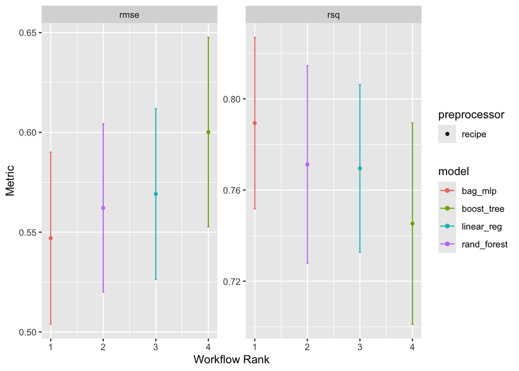

```r
autoplot(wf)
```

```r
rank_results(wf, rank_metric = "rsq", select_best = TRUE)
```

```
# A tibble: 8 × 9
  wflow_id          .config .metric  mean std_err     n preprocessor model  rank
  <chr>             <chr>   <chr>   <dbl>   <dbl> <int> <chr>        <chr> <int>
1 recipe_bag_mlp    Prepro… rmse    0.547  0.0262    10 recipe       bag_…     1
2 recipe_bag_mlp    Prepro… rsq     0.789  0.0228    10 recipe       bag_…     1
3 recipe_rand_fore… Prepro… rmse    0.562  0.0256    10 recipe       rand…     2
4 recipe_rand_fore… Prepro… rsq     0.771  0.0264    10 recipe       rand…     2
5 recipe_linear_reg Prepro… rmse    0.569  0.0260    10 recipe       line…     3
6 recipe_linear_reg Prepro… rsq     0.770  0.0223    10 recipe       line…     3
7 recipe_boost_tree Prepro… rmse    0.600  0.0289    10 recipe       boos…     4
8 recipe_boost_tree Prepro… rsq     0.745  0.0268    10 recipe       boos…     4
```

#### Which of the 4 models would you move forward with?

I can see that the bag_mlp model outranks the other functions, so I would move forward with it.

## Question 4

#### Borrowing from the workflow presented above, build your own complete ML pipeline to predict mean streamflow using the CAMELS dataset. You can experiment with different predictors and preprocessing steps to see how they impact model performance. A successful model will have a R-squared value > 0.9.

## 4a: Data Spliting

```r
# Set a seed for reproducible
set.seed(123)

camels <- camels |>
  mutate(logQmean = log(q_mean))

# Create an initial split with 75% used for training and 25% for testing
split_data <- initial_split(camels, prop = 0.75)

# Extract your training and testing sets
train_data <- training(split_data)
test_data <- testing(split_data)

# Build a 10-fold CV dataset
cv_splits <- vfold_cv(train_data, v = 10)
```

## 4b: Recipe

```r
camels |>
  select(q_mean, low_prec_freq, gvf_max) |>
  drop_na() |>
  cor()
```

```
                  q_mean low_prec_freq    gvf_max
q_mean         1.0000000    -0.7145711  0.4149484
low_prec_freq -0.7145711     1.0000000 -0.6478606
gvf_max        0.4149484    -0.6478606  1.0000000
```

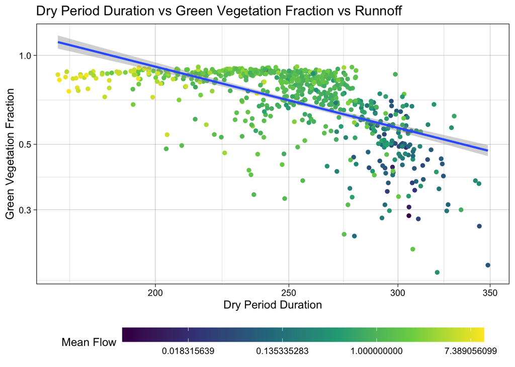

```r
ggplot(camels, aes(x = low_prec_freq, y = gvf_max)) +
  geom_point(aes(color = q_mean)) +
  geom_smooth(method = "lm") +
  # Apply a log transformation to the color scale
  scale_color_viridis_c(trans = "log") +
  scale_x_log10() +
  scale_y_log10() +
  theme_linedraw() +
  theme(legend.position = "bottom",
        # Expand the legend width ...
        legend.key.width = unit(2.5, "cm"),
        legend.key.height = unit(.5, "cm")) +
  labs(title = "Dry Period Duration vs Green Vegetation Fraction vs Runnoff",
       x = "Dry Period Duration",
       y = "Green Vegetation Fraction",
       color = "Mean Flow")
```

#### Define a formula you want to use to predict logQmean

```r
formula <- logQmean ~ low_prec_freq + gvf_max
```

#### Build a recipe that you feel handles the predictors chosen well

```r
recipe <- recipe(formula, data = train_data) |>
  step_log(all_predictors()) |>
  step_interact(terms = ~ low_prec_freq:gvf_max) |>
  step_naomit(all_predictors(), all_outcomes())
```

## 4c: Define 3 models

#### Define a random forest model using the rand_forest function. Set the engine to ranger and the mode to regression. Define two other models of your choice

```r
new_rf_model <- rand_forest() |>
  set_engine("ranger", importance = "impurity") |>
  set_mode("regression")

new_bt_model <- boost_tree() |>
  set_engine("xgboost") |>
  set_mode("regression")

new_bag_model <- bag_mlp() |>
  set_engine("nnet") |>
  set_mode("regression")
```

## 4d: Workflow set ()

#### With your preprocessing steps and models defined, you can now build a workflow_set object to fit and evaluate your models. This will allow you to compare the performance of different models on the same data

```r
workflow_set <- workflow_set(list(recipe), list(new_rf_model, new_bt_model, new_bag_model)) |>
  workflow_map('fit_resamples', resamples = cv_splits)
```

## 4e: Evaluation

#### Use autoplot and rank_results to compare the models

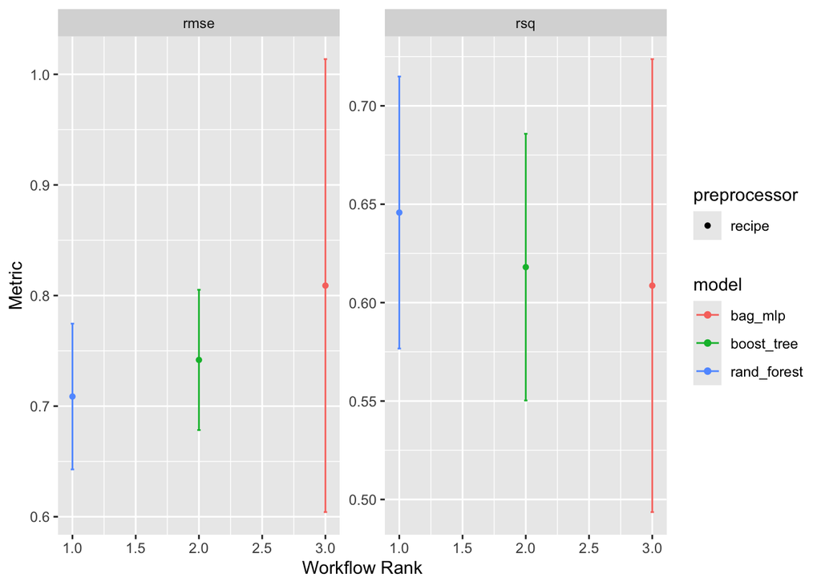

```r
autoplot(workflow_set)
```

```r
rank_results(workflow_set, rank_metric = "rsq", select_best = TRUE)
```

```
# A tibble: 6 × 9
  wflow_id          .config .metric  mean std_err     n preprocessor model  rank
  <chr>             <chr>   <chr>   <dbl>   <dbl> <int> <chr>        <chr> <int>
1 recipe_rand_fore… Prepro… rmse    0.709  0.0401    10 recipe       rand…     1
2 recipe_rand_fore… Prepro… rsq     0.646  0.0420    10 recipe       rand…     1
3 recipe_boost_tree Prepro… rmse    0.742  0.0385    10 recipe       boos…     2
4 recipe_boost_tree Prepro… rsq     0.618  0.0412    10 recipe       boos…     2
5 recipe_bag_mlp    Prepro… rmse    0.809  0.125     10 recipe       bag_…     3
6 recipe_bag_mlp    Prepro… rsq     0.609  0.0700    10 recipe       bag_…     3
```

#### Describe what model you think is best and why

It looks like the random forest model is the best because it has the highest R-squared value (closest to a value of 1).

## 4f: Extact and Evaluate

# Now that you found your favorite model, lets see how it does on the test data

```r
# Build a workflow (not workflow set) with your favorite model, recipe, and training data
# Use fit to fit all training data to the model
# Use augment to make predictions on the test data
final_workflow <- workflow() |>
  add_recipe(recipe) |>
  add_model(new_rf_model) |>
  fit(data = train_data) |>
  augment(new_data = test_data)

metrics(final_workflow, truth = logQmean, estimate = .pred)
```

```
# A tibble: 3 × 3
  .metric .estimator .estimate
  <chr>   <chr>          <dbl>
1 rmse    standard       0.668
2 rsq     standard       0.645
3 mae     standard       0.468
```

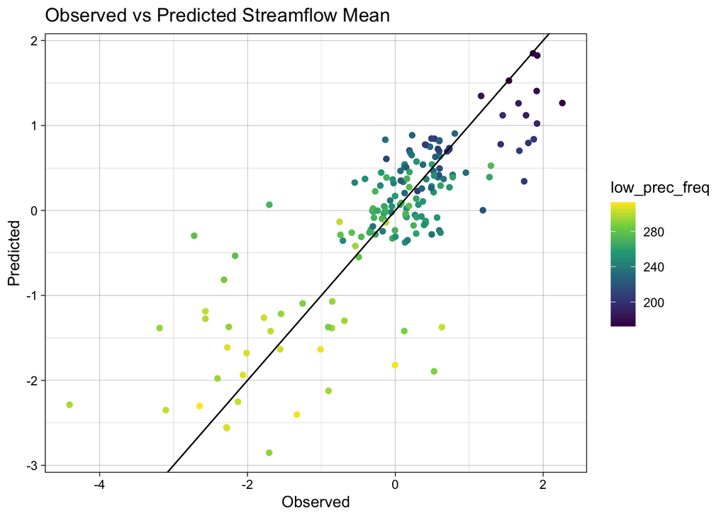

```r
# Create a plot of the observed vs predicted values with clear title, axis labels, and a compelling color scale
ggplot(final_workflow, aes(x = logQmean, y = .pred, colour = low_prec_freq)) +
  scale_color_viridis_c() +
  geom_point() +
  geom_abline() +
  theme_linedraw() +
  labs(title = "Observed vs Predicted Streamflow Mean",
       x = "Observed",
       y = "Predicted")
```

#### Describe what you think of the results

My model has a R-squared value of ~ 0.6446, meaning my model explains about 64.5% of the variation in streamflow based on average duration of dry periods and green vegetation fraction. I would say it is a decent model, given that streamflow has many other factors that influence it but I only used 2 predictors and still got an R-squared above 0.6. However, my model still doesn’t explain around 35.5% of variability in streamflow. Overall, I would say my model is moderately successful.